# Advanced sliding with nonstandard outputs

In this vignette, we discuss how to use the sliding functionality in the `epiprocess` package with less common grouping schemes or with computations that have advanced output structures. The output of a slide computation should either be an atomic value/vector, or a data frame. This data frame can have multiple columns, multiple rows, or both.

During basic usage (e.g., when all optional arguments are set to their defaults):

- `epi_slide(edf, <computation>, .....)`:
  - keeps **all** columns of `edf`, adds computed column(s)
  - outputs **one row per row in `edf`** (recycling outputs from computations appropriately if there are multiple time series bundled together inside any group(s))
  - maintains the grouping or ungroupedness of `edf`
  - is roughly analogous to (the non-sliding) **`dplyr::mutate` followed by `dplyr::arrange(time_value, .by_group = TRUE)`**
  - outputs an **`epi_df`** if the required columns are present, otherwise a tibble
- `epix_slide(ea, <computation>, .....)`:
  - keeps **grouping and `time_value`** columns of `ea`, adds computed column(s)
  - outputs **any number of rows** (computations are allowed to output any number of elements/rows, and no recycling is performed)
  - maintains the grouping or ungroupedness of `ea`, unless it was explicitly grouped by zero variables; this isn’t supported by `grouped_df` and it will automatically turn into an ungrouped tibble
  - is roughly analogous to (the non-sliding) **`dplyr::group_modify`**
  - outputs a **tibble**

These differences in basic behavior make some common slide operations require less boilerplate:

- predictors and targets calculated with `epi_slide` are automatically lined up with each other and with the signals from which they were calculated; and
- computations for an `epix_slide` can output data frames with any number of rows, containing models, forecasts, evaluations, etc., and will not be recycled.

When using more advanced features, more complex rules apply:

- Generalization: `epi_slide(edf, ....., ref_time_values=my_ref_time_values)` will output one row for every row in `edf` with `time_value` appearing inside `my_ref_time_values`, and is analogous to a `dplyr::mutate`&`dplyr::arrange` followed by `dplyr::filter` to those `ref_time_values`. We call this property **size stability**, and describe how it is achieved in the following sections. The default behavior described above is a special case of this general rule based on a default value of `ref_time_values`.
- Exception/feature: `epi_slide(edf, ....., ref_time_values=my_ref_time_values, all_rows=TRUE)` will not just output rows for `my_ref_time_values`, but instead will output one row per row in `edf`.
- Exception/feature: `epi_slide(edf, ....., as_list_col=TRUE)` will format the output to add a single list-class computed column.
- Exception/feature: `epix_slide(ea, ....., as_list_col=TRUE)` will format the output to have one row per computation and a single list-class computed column (in addition to the grouping variables and `time_value`), as if we had used `tidyr::chop()` or `tidyr::nest()`.
- Clarification: `ea %>% group_by(....., .drop=FALSE) %>% epix_slide(<computation>, .....)` will call the computation on any missing groups according to `dplyr`’s `.drop=FALSE` rules, resulting in additional output rows.

Below we demonstrate some advanced use cases of sliding with different output structures. We focus on `epi_slide()` for the most part, though some of the behavior we demonstrate also carries over to `epix_slide()`.

## Recycling outputs

When a computation returns a single atomic value, `epi_slide()` will internally try to recycle the output so that it is size stable (in the sense described above). We can use this to our advantage, for example, in order to compute a trailing average marginally over geo values, which we demonstrate below in a simple synthetic example.

```r
library(epiprocess)
library(dplyr)
set.seed(123)

edf <- tibble(
  geo_value = rep(c("ca", "fl", "pa"), each = 3),
  time_value = rep(seq(as.Date("2020-06-01"), as.Date("2020-06-03"), by = "day"), length.out = length(geo_value)),
  x = seq_along(geo_value) + 0.01 * rnorm(length(geo_value)),
) %>%
  as_epi_df(as_of = as.Date("2024-03-20"))

# 2-day trailing average, per geo value
edf %>%
  group_by(geo_value) %>%
  epi_slide(x_2dav = mean(x), before = 1) %>%
  ungroup()
```

```
## An `epi_df` object, 9 x 4 with metadata:
## * geo_type  = state
## * time_type = day
## * as_of     = 2024-03-20
##
## # A tibble: 9 × 4
##   geo_value time_value     x x_2dav
## * <chr>     <date>     <dbl>  <dbl>
## 1 ca        2020-06-01 0.994  0.994
## 2 ca        2020-06-02 2.00   1.50
## 3 ca        2020-06-03 3.02   2.51
## 4 fl        2020-06-01 4.00   4.00
## 5 fl        2020-06-02 5.00   4.50
## 6 fl        2020-06-03 6.02   5.51
## 7 pa        2020-06-01 7.00   7.00
## 8 pa        2020-06-02 7.99   7.50
## 9 pa        2020-06-03 8.99   8.49
```

```r
# 2-day trailing average, marginally
edf %>%
  epi_slide(x_2dav = mean(x), before = 1)
```

```
## An `epi_df` object, 9 x 4 with metadata:
## * geo_type  = state
## * time_type = day
## * as_of     = 2024-03-20
##
## # A tibble: 9 × 4
##   geo_value time_value     x x_2dav
## * <chr>     <date>     <dbl>  <dbl>
## 1 ca        2020-06-01 0.994   4.00
## 2 fl        2020-06-01 4.00    4.00
## 3 pa        2020-06-01 7.00    4.00
## 4 ca        2020-06-02 2.00    4.50
## 5 fl        2020-06-02 5.00    4.50
## 6 pa        2020-06-02 7.99    4.50
## 7 ca        2020-06-03 3.02    5.50
## 8 fl        2020-06-03 6.02    5.50
## 9 pa        2020-06-03 8.99    5.50
```

When the slide computation returns an atomic vector (rather than a single value) `epi_slide()` checks whether its return length ensures size stability, and if so, uses it to fill the new column. For example, this next computation gives the same result as the last one.

```r
edf %>%
  epi_slide(y_2dav = rep(mean(x), 3), before = 1)
```

```
## An `epi_df` object, 9 x 4 with metadata:
## * geo_type  = state
## * time_type = day
## * as_of     = 2024-03-20
##
## # A tibble: 9 × 4
##   geo_value time_value     x y_2dav
## * <chr>     <date>     <dbl>  <dbl>
## 1 ca        2020-06-01 0.994   4.00
## 2 fl        2020-06-01 4.00    4.00
## 3 pa        2020-06-01 7.00    4.00
## 4 ca        2020-06-02 2.00    4.50
## 5 fl        2020-06-02 5.00    4.50
## 6 pa        2020-06-02 7.99    4.50
## 7 ca        2020-06-03 3.02    5.50
## 8 fl        2020-06-03 6.02    5.50
## 9 pa        2020-06-03 8.99    5.50
```

However, if the output is an atomic vector (rather than a single value) and it is *not* size stable, then `epi_slide()` throws an error. For example, below we are trying to return 2 things for 3 states.

```r
edf %>%
  epi_slide(x_2dav = rep(mean(x), 2), before = 1)
```

```
## Error in `.f()`:
## ! The slide computations must either (a) output a single element/row
##   each, or (b) one element/row per appearance of the reference time value in
##   the local window.
```

## Multi-column outputs

Now we move on to outputs that are data frames with a single row but multiple columns. Working with this type of output structure has in fact has already been demonstrated in the [slide vignette](https://cmu-delphi.github.io/epiprocess/articles/slide.html). When we set `as_list_col = TRUE` in the call to `epi_slide()`, the resulting `epi_df` object returned by `epi_slide()` has a list column containing the slide values.

```r
edf2 <- edf %>%
  group_by(geo_value) %>%
  epi_slide(
    a = data.frame(x_2dav = mean(x), x_2dma = mad(x)),
    before = 1, as_list_col = TRUE
  ) %>%
  ungroup()

class(edf2$a)
```

```
## [1] "list"
```

```r
length(edf2$a)
```

```
## [1] 9
```

```r
edf2$a[[2]]
```

```
##     x_2dav    x_2dma
## 1 1.496047 0.7437485
```

When we use `as_list_col = FALSE` (the default in `epi_slide()`), the function unnests (in the sense of `tidyr::unnest()`) the list column `a`, so that the resulting `epi_df` has multiple new columns containing the slide values. The default is to name these unnested columns by prefixing the name assigned to the list column (here `a`) onto the column names of the output data frame from the slide computation (here `x_2dav` and `x_2dma`) separated by "_".

```r
edf %>%
  group_by(geo_value) %>%
  epi_slide(
    a = data.frame(x_2dav = mean(x), x_2dma = mad(x)),
    before = 1, as_list_col = FALSE
  ) %>%
  ungroup()
```

```
## An `epi_df` object, 9 x 5 with metadata:
## * geo_type  = state
## * time_type = day
## * as_of     = 2024-03-20
##
## # A tibble: 9 × 5
##   geo_value time_value     x a_x_2dav a_x_2dma
## * <chr>     <date>     <dbl>    <dbl>    <dbl>
## 1 ca        2020-06-01 0.994    0.994    0
## 2 ca        2020-06-02 2.00     1.50     0.744
## 3 ca        2020-06-03 3.02     2.51     0.755
## 4 fl        2020-06-01 4.00     4.00     0
## 5 fl        2020-06-02 5.00     4.50     0.742
## 6 fl        2020-06-03 6.02     5.51     0.753
## 7 pa        2020-06-01 7.00     7.00     0
## 8 pa        2020-06-02 7.99     7.50     0.729
## 9 pa        2020-06-03 8.99     8.49     0.746
```

We can use `names_sep = NULL` (which gets passed to `tidyr::unnest()`) to drop the prefix associated with list column name, in naming the unnested columns.

```r
edf %>%
  group_by(geo_value) %>%
  epi_slide(
    a = data.frame(x_2dav = mean(x), x_2dma = mad(x)),
    before = 1, as_list_col = FALSE, names_sep = NULL
  ) %>%
  ungroup()
```

```
## An `epi_df` object, 9 x 5 with metadata:
## * geo_type  = state
## * time_type = day
## * as_of     = 2024-03-20
##
## # A tibble: 9 × 5
##   geo_value time_value     x x_2dav x_2dma
## * <chr>     <date>     <dbl>  <dbl>  <dbl>
## 1 ca        2020-06-01 0.994  0.994  0
## 2 ca        2020-06-02 2.00   1.50   0.744
## 3 ca        2020-06-03 3.02   2.51   0.755
## 4 fl        2020-06-01 4.00   4.00   0
## 5 fl        2020-06-02 5.00   4.50   0.742
## 6 fl        2020-06-03 6.02   5.51   0.753
## 7 pa        2020-06-01 7.00   7.00   0
## 8 pa        2020-06-02 7.99   7.50   0.729
## 9 pa        2020-06-03 8.99   8.49   0.746
```

Furthermore, `epi_slide()` will recycle the single row data frame as needed in order to make the result size stable, just like the case for atomic values.

```r
edf %>%
  epi_slide(
    a = data.frame(x_2dav = mean(x), x_2dma = mad(x)),
    before = 1, as_list_col = FALSE, names_sep = NULL
  )
```

```
## An `epi_df` object, 9 x 5 with metadata:
## * geo_type  = state
## * time_type = day
## * as_of     = 2024-03-20
##
## # A tibble: 9 × 5
##   geo_value time_value     x x_2dav x_2dma
## * <chr>     <date>     <dbl>  <dbl>  <dbl>
## 1 ca        2020-06-01 0.994   4.00   4.45
## 2 fl        2020-06-01 4.00    4.00   4.45
## 3 pa        2020-06-01 7.00    4.00   4.45
## 4 ca        2020-06-02 2.00    4.50   3.71
## 5 fl        2020-06-02 5.00    4.50   3.71
## 6 pa        2020-06-02 7.99    4.50   3.71
## 7 ca        2020-06-03 3.02    5.50   3.69
## 8 fl        2020-06-03 6.02    5.50   3.69
## 9 pa        2020-06-03 8.99    5.50   3.69
```

## Multi-row outputs

For a slide computation that outputs a data frame with more than one row, the behavior is analogous to a slide computation that outputs an atomic vector. Meaning, `epi_slide()` will check that the result is size stable, and if so, will fill the new column(s) in the resulting `epi_df` object appropriately.

This can be convenient for modeling in the following sense: we can, for example, fit a sliding, data-versioning-unaware nowcasting or forecasting model by pooling data from different locations, and then return separate forecasts from this common model for each location. We use our synthetic example to demonstrate this idea abstractly but simply by forecasting (actually, nowcasting) `y` from `x` by fitting a time-windowed linear model that pooling data across all locations.

```r
edf$y <- 2 * edf$x + 0.05 * rnorm(length(edf$x))

edf %>%
  epi_slide(function(d, ...) {
    obj <- lm(y ~ x, data = d)
    return(
      as.data.frame(
        predict(obj,
          newdata = d %>%
            group_by(geo_value) %>%
            filter(time_value == max(time_value)),
          interval = "prediction", level = 0.9
        )
      )
    )
  }, before = 1, new_col_name = "fc", names_sep = NULL)
```

```
## An `epi_df` object, 9 x 7 with metadata:
## * geo_type  = state
## * time_type = day
## * as_of     = 2024-03-20
##
## # A tibble: 9 × 7
##   geo_value time_value     x     y   fit   lwr   upr
## * <chr>     <date>     <dbl> <dbl> <dbl> <dbl> <dbl>
## 1 ca        2020-06-01 0.994  1.97  1.96  1.87  2.06
## 2 fl        2020-06-01 4.00   8.02  8.03  7.95  8.11
## 3 pa        2020-06-01 7.00  14.1  14.1  14.0  14.2
## 4 ca        2020-06-02 2.00   4.06  4.01  3.91  4.11
## 5 fl        2020-06-02 5.00  10.0  10.0   9.94 10.1
## 6 pa        2020-06-02 7.99  16.0  16.0  15.9  16.1
## 7 ca        2020-06-03 3.02   6.05  6.07  5.96  6.17
## 8 fl        2020-06-03 6.02  12.0  12.0  11.9  12.1
## 9 pa        2020-06-03 8.99  17.9  17.9  17.8  18.0
```

The above example focused on simplicity to show how to work with multi-row outputs. Note however, the following issues in this example:

- The `lm` fitting data includes the testing instances, as no training-test split was performed.
- Adding a simple training-test split would not factor in reporting latency properly.
- Data revisions are not taken into account.

All three of these factors contribute to unrealistic retrospective forecasts and overly optimistic retrospective performance evaluations. Instead, one should favor an `epix_slide` for more realistic “pseudoprospective” forecasts. Using `epix_slide` also makes it easier to express certain types of forecasts; while in `epi_slide`, forecasts for additional aheads or quantile levels would need to be expressed as additional columns, or nested inside list columns, `epix_slide` does not perform size stability checks or recycling, allowing computations to output any number of rows.

## Version-aware forecasting, revisited

We revisit the COVID-19 forecasting example from the [archive vignette](https://cmu-delphi.github.io/epiprocess/articles/slide.html) in order to demonstrate the preceding points regarding forecast evaluation in a more realistic setting. First, we fetch the versioned data and build the archive.

```r
library(epidatr)
library(data.table)
library(ggplot2)
theme_set(theme_bw())

y1 <- pub_covidcast(
  source = "doctor-visits",
  signals = "smoothed_adj_cli",
  geo_type = "state",
  time_type = "day",
  geo_values = "ca,fl",
  time_value = epirange(20200601, 20211201),
  issues = epirange(20200601, 20211201)
)

y2 <- pub_covidcast(
  source = "jhu-csse",
  signal = "confirmed_7dav_incidence_prop",
  geo_type = "state",
  time_type = "day",
  geo_values = "ca,fl",
  time_value = epirange(20200601, 20211201),
  issues = epirange(20200601, 20211201)
)

x <- y1 %>%
  select(geo_value, time_value,
    version = issue,
    percent_cli = value
  ) %>%
  as_epi_archive(compactify = FALSE)

# mutating merge operation:
x <- epix_merge(
  x,
  y2 %>%
    select(geo_value, time_value,
      version = issue,
      case_rate_7d_av = value
    ) %>%
    as_epi_archive(compactify = FALSE),
  sync = "locf",
  compactify = FALSE
)
```

Next, we extend the ARX function to handle multiple geo values, since in the present case, we will not be grouping by geo value and each slide computation will be run on multiple geo values at once. Note that, because `epix_slide()` only returns the grouping variables, `time_value`, and the slide computations in the eventual returned tibble, we need to include `geo_value` as a column in the output data frame from our ARX computation.

```r
library(tidyr)
library(purrr)
prob_arx_args <- function(lags = c(0, 7, 14),
                          ahead = 7,
                          min_train_window = 20,
                          lower_level = 0.05,
                          upper_level = 0.95,
                          symmetrize = TRUE,
                          intercept = FALSE,
                          nonneg = TRUE) {
  return(list(
    lags = lags,
    ahead = ahead,
    min_train_window = min_train_window,
    lower_level = lower_level,
    upper_level = upper_level,
    symmetrize = symmetrize,
    intercept = intercept,
    nonneg = nonneg
  ))
}

prob_arx <- function(x, y, geo_value, time_value, args = prob_arx_args()) {
  # Return NA if insufficient training data
  if (length(y) < args$min_train_window + max(args$lags) + args$ahead) {
    return(data.frame(
      geo_value = unique(geo_value), # Return geo value!
      point = NA, lower = NA, upper = NA
    ))
  }

  # Set up x, y, lags list
  if (!missing(x)) {
    x <- data.frame(x, y)
  } else {
    x <- data.frame(y)
  }
  if (!is.list(args$lags)) args$lags <- list(args$lags)
  args$lags <- rep(args$lags, length.out = ncol(x))

  # Build features and response for the AR model, and then fit it
  dat <-
    tibble(i = seq_len(ncol(x)), lag = args$lags) %>%
    unnest(lag) %>%
    mutate(name = paste0("x", seq_len(nrow(.)))) %>% # nolint: object_usage_linter
    # One list element for each lagged feature
    pmap(function(i, lag, name) {
      tibble(
        geo_value = geo_value,
        time_value = time_value + lag, # Shift back
        !!name := x[, i]
      )
    }) %>%
    # One list element for the response vector
    c(list(
      tibble(
        geo_value = geo_value,
        time_value = time_value - args$ahead, # Shift forward
        y = y
      )
    )) %>%
    # Combine them together into one data frame
    reduce(full_join, by = c("geo_value", "time_value")) %>%
    arrange(time_value)
  if (args$intercept) dat$x0 <- rep(1, nrow(dat))
  obj <- lm(y ~ . + 0, data = select(dat, -geo_value, -time_value))

  # Use LOCF to fill NAs in the latest feature values (do this by geo value)
  setDT(dat) # Convert to a data.table object by reference
  cols <- setdiff(names(dat), c("geo_value", "time_value"))
  dat[, (cols) := nafill(.SD, type = "locf"), .SDcols = cols, by = "geo_value"]

  # Make predictions
  test_time_value <- max(time_value)
  point <- predict(
    obj,
    newdata = dat %>%
      dplyr::group_by(geo_value) %>%
      dplyr::filter(time_value == test_time_value)
  )

  # Compute bands
  r <- residuals(obj)
  s <- ifelse(args$symmetrize, -1, NA) # Should the residuals be symmetrized?
  q <- quantile(c(r, s * r), probs = c(args$lower, args$upper), na.rm = TRUE)
  lower <- point + q[1]
  upper <- point + q[2]

  # Clip at zero if we need to, then return
  if (args$nonneg) {
    point <- pmax(point, 0)
    lower <- pmax(lower, 0)
    upper <- pmax(upper, 0)
  }
  return(data.frame(
    geo_value = unique(geo_value), # Return geo value!
    point = point, lower = lower, upper = upper
  ))
}
```

We now make forecasts on the archive and compare to forecasts on the latest data.

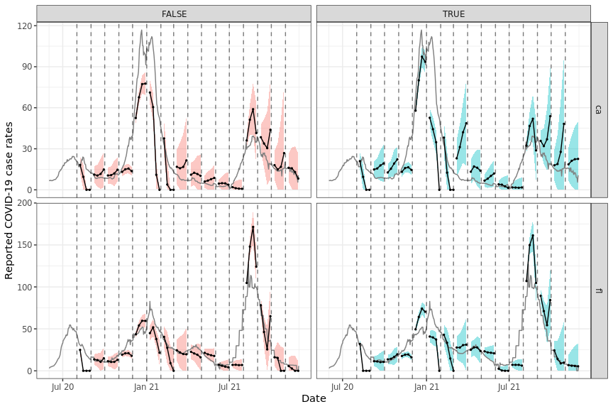

```r
# Latest snapshot of data, and forecast dates
x_latest <- epix_as_of(x, max_version = max(x$DT$version))
fc_time_values <- seq(as.Date("2020-08-01"),
  as.Date("2021-11-30"),
  by = "1 month"
)

# Simple function to produce forecasts k weeks ahead
k_week_ahead <- function(x, ahead = 7, as_of = TRUE) {
  if (as_of) {
    x %>%
      epix_slide(
        fc = prob_arx(.data$percent_cli, .data$case_rate_7d_av, .data$geo_value, .data$time_value,
          args = prob_arx_args(ahead = ahead)
        ),
        before = 119, ref_time_values = fc_time_values
      ) %>%
      mutate(
        target_date = .data$time_value + ahead, as_of = TRUE,
        geo_value = .data$fc_geo_value
      )
  } else {
    x_latest %>%
      epi_slide(
        fc = prob_arx(.data$percent_cli, .data$case_rate_7d_av, .data$geo_value, .data$time_value,
          args = prob_arx_args(ahead = ahead)
        ),
        before = 119, ref_time_values = fc_time_values
      ) %>%
      mutate(target_date = .data$time_value + ahead, as_of = FALSE)
  }
}

# Generate the forecasts, and bind them together
fc <- bind_rows(
  k_week_ahead(x, ahead = 7, as_of = TRUE),
  k_week_ahead(x, ahead = 14, as_of = TRUE),
  k_week_ahead(x, ahead = 21, as_of = TRUE),
  k_week_ahead(x, ahead = 28, as_of = TRUE),
  k_week_ahead(x, ahead = 7, as_of = FALSE),
  k_week_ahead(x, ahead = 14, as_of = FALSE),
  k_week_ahead(x, ahead = 21, as_of = FALSE),
  k_week_ahead(x, ahead = 28, as_of = FALSE)
)

# Plot them, on top of latest COVID-19 case rates
ggplot(fc, aes(x = target_date, group = time_value, fill = as_of)) +
  geom_ribbon(aes(ymin = fc_lower, ymax = fc_upper), alpha = 0.4) +
  geom_line(
    data = x_latest, aes(x = time_value, y = case_rate_7d_av),
    inherit.aes = FALSE, color = "gray50"
  ) +
  geom_line(aes(y = fc_point)) +
  geom_point(aes(y = fc_point), size = 0.5) +
  geom_vline(aes(xintercept = time_value), linetype = 2, alpha = 0.5) +
  facet_grid(vars(geo_value), vars(as_of), scales = "free") +
  scale_x_date(minor_breaks = "month", date_labels = "%b %y") +
  labs(x = "Date", y = "Reported COVID-19 case rates") +
  theme(legend.position = "none")
```

We can see that these forecasts, which come from training an ARX model jointly over CA and FL, exhibit generally less variability and wider prediction bands compared to the ones from the archive vignette, which come from training a separate ARX model on each state. As in the archive vignette, we can see a difference between version-aware (right column) and -unaware (left column) forecasting, as well.

## Attribution

The `case_rate_7d_av` data used in this document is a modified part of the [COVID-19 Data Repository by the Center for Systems Science and Engineering (CSSE) at Johns Hopkins University](https://github.com/CSSEGISandData/COVID-19) as [republished in the COVIDcast Epidata API](https://cmu-delphi.github.io/delphi-epidata/api/covidcast-signals/jhu-csse.html). This data set is licensed under the terms of the [Creative Commons Attribution 4.0 International license](https://creativecommons.org/licenses/by/4.0/) by the Johns Hopkins University on behalf of its Center for Systems Science in Engineering. Copyright Johns Hopkins University 2020.

The `percent_cli` data is a modified part of the [COVIDcast Epidata API Doctor Visits data](https://cmu-delphi.github.io/delphi-epidata/api/covidcast-signals/doctor-visits.html). This dataset is licensed under the terms of the [Creative Commons Attribution 4.0 International license](https://creativecommons.org/licenses/by/4.0/). Copyright Delphi Research Group at Carnegie Mellon University 2020.